# Racing

### Author Details:

| Name | Address | Email | Organization |
| --- | --- | --- | --- |
| Subash Prakash | Ernst Lehmann Strasse-2, Magdeburg - 39106,Germany | subashprakash8@gmail.com | Master Student |

[figure not shown]

## Racing

Racing on tracks could be easier somedays when the weather is good while sometimes it could be impossible to drive. One such analysis of the dataset is racing.

Certain analysis questions to ask:

```
1. Does weather depend on winning/retiring races ?
2. How does fuel affect to winning?
3. How much money is spent on racing?
5. What are some yearly distributions?
4. Can we predict the status of a race given some conditions?
```

All of the above question makes it interesting to explore and understand the racing dataset.

Data Description:

#### ID:

The ID of the entry

#### race_created:

When was the race scheduled?

#### race_driven:

When was the race held?

#### track_id:

ID of the race track on which the race was held.

#### challenger:

userID of the challenger

#### opponent:

userID of the opponent (challenged)

#### money:

use of the race (in EUR)

#### fuel_consumption:

Fuel consumption of participants during the race (in l)

#### winner:

winner of the race (userID)

#### status:

The status of the race. Possible are: waiting, finished, retired, declined

#### Forecast:

weather forecast for the race. The field (the CSV file is an export from a (My) SQL database) is a serialized array. This means that an array data type is stored as a string in the database. The background is that you do not want to have your own field in the table of the database for each value in the array. But now to the data itself. I want to explain data to you using the string from the "forecast" field of the first line: a: 4: {s: 5: "sunny"; i: 10; s: 5: "rainy"; i: 70; s: 8: "thundery"; i: 0; s: 5: "snowy"; i: 20;} The a: 4 means that it is a serialized array of 4 pairs of data. The content of the array is then in the curly brackets. Each data pair represents a weather type and the probability of their occurrence. The weather types (entries in the array) are separated by semicolons. There are four types of weather (sunny, rainy, thundery, snowy). In front of it is "s:" and a number. The number only describes the length of the following string (sunny 5 characters, thundery 8, etc.). Behind the weather type is still an "i:" and a number. The number after the i (for integer) describes the percentage probability of occurrence of the respective weather.

The above entry means broken down: 10% sunny weather (probability) 70% rainy weather (probability) 0% thunderstorm 20% snowfall

#### weather:

Actual weather

```python
import numpy as np
import pandas as pd
import matplotlib.pyplot as plt
import seaborn as sns
%matplotlib inline
%config IPCompleter.greedy=True
```

```python
sns.set_palette("Dark2")
sns.set_style("whitegrid")
```

#### Import the data from the location

```python
race = pd.read_csv("races.csv",sep=";")
```

```python
race.head(6)
```

|  | id | race_created | race_driven | track_id | challenger | opponent | money | fuel_consumption | winner | status | forecast | weather |
| --- | --- | --- | --- | --- | --- | --- | --- | --- | --- | --- | --- | --- |
| 0 | 1 | 06.03.2012 | 06.03.2012 00:00 | 12 | 5 | 2 | 30 | 0.63 | 5 | finished | a:4:{s:5:"sunny";i:10;s:5:"rainy";i:70;s:8:"th... | rainy |
| 1 | 2 | 06.03.2012 | 06.03.2012 00:03 | 12 | 5 | 4 | 30 | 0.63 | 4 | finished | a:4:{s:5:"sunny";i:70;s:5:"rainy";i:15;s:8:"th... | sunny |
| 2 | 3 | 06.03.2012 | 0000-00-00 00:00:00 | 3 | 10 | 5 | 30 | 0.63 | 0 | declined | a:4:{s:5:"sunny";i:70;s:5:"rainy";i:10;s:8:"th... | NaN |
| 3 | 4 | 06.03.2012 | 06.03.2012 00:06 | 12 | 5 | 4 | 30 | 0.63 | 5 | finished | a:4:{s:5:"sunny";i:25;s:5:"rainy";i:75;s:8:"th... | sunny |
| 4 | 5 | 06.03.2012 | 0000-00-00 00:00:00 | 12 | 4 | 5 | 30 | 0.63 | 0 | declined | a:4:{s:5:"sunny";i:45;s:5:"rainy";i:20;s:8:"th... | NaN |
| 5 | 6 | 06.03.2012 | 06.03.2012 00:17 | 12 | 5 | 10 | 100 | 0.63 | 5 | finished | a:4:{s:5:"sunny";i:30;s:5:"rainy";i:20;s:8:"th... | snowy |

## Information:

As seen from head, now we are able to explore the dataset to see some values. If can see that some values for weather are Nan when status of the race is declined. Also, when declined race_driven date is dummy value.

```python
# To understand about each attributes we use info()
race.info()
```

```
<class 'pandas.core.frame.DataFrame'>
RangeIndex: 166609 entries, 0 to 166608
Data columns (total 12 columns):
id                  166609 non-null int64
race_created        166609 non-null object
race_driven         166609 non-null object
track_id            166609 non-null int64
challenger          166609 non-null int64
opponent            166609 non-null int64
money               166609 non-null int64
fuel_consumption    166609 non-null object
winner              166609 non-null int64
status              166609 non-null object
forecast            166609 non-null object
weather             109099 non-null object
dtypes: int64(6), object(6)
memory usage: 15.3+ MB
```

### Distribution of Status accross the dataset:

We can see from the plot that status of the race can be (finished, declined, retired, waiting). We can also observe that most of the dataset have either Finished races or retired races

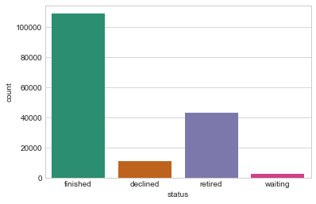

```python
sns.countplot(x="status",data=race)
```

### An interesting observation can be made by plotting track_id frequencies.

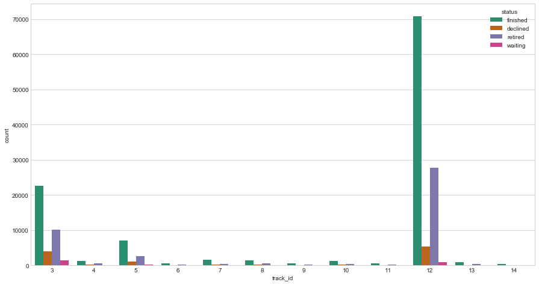

```python
plt.figure(figsize=(15,8))
sns.countplot(x="track_id",data=race,hue="status")
```

```python
#### Create a creation year of races for more exploration on data
```

```python
race["race_created_year"] = race.race_created.apply(lambda x: x.split(".")[2])
```

```python
race.head(3)
```

|  | id | race_created | race_driven | track_id | challenger | opponent | money | fuel_consumption | winner | status | forecast | weather | race_created_year |
| --- | --- | --- | --- | --- | --- | --- | --- | --- | --- | --- | --- | --- | --- |
| 0 | 1 | 06.03.2012 | 06.03.2012 00:00 | 12 | 5 | 2 | 30 | 0.63 | 5 | finished | a:4:{s:5:"sunny";i:10;s:5:"rainy";i:70;s:8:"th... | rainy | 2012 |
| 1 | 2 | 06.03.2012 | 06.03.2012 00:03 | 12 | 5 | 4 | 30 | 0.63 | 4 | finished | a:4:{s:5:"sunny";i:70;s:5:"rainy";i:15;s:8:"th... | sunny | 2012 |
| 2 | 3 | 06.03.2012 | 0000-00-00 00:00:00 | 3 | 10 | 5 | 30 | 0.63 | 0 | declined | a:4:{s:5:"sunny";i:70;s:5:"rainy";i:10;s:8:"th... | NaN | 2012 |

#### A Distribution plot over the years on races

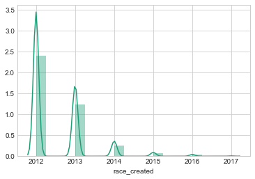

```python
sns.distplot(race.race_created.apply(lambda x:int(x.split(".")[2])),bins=20)
```

```python
counts = race.groupby("race_created_year").count()
d= {"Year":counts.index,"Freq":counts.id}
```

```python
sum_money = race.groupby("race_created_year").mean()
d1= {"Year":sum_money.index,"Average_money":sum_money.money}
```

```python
race_years_counts = pd.DataFrame(d)
race_years_counts.head()
```

| race_created_year | Freq | Year |
| --- | --- | --- |
| 2012 | 100035 | 2012 |
| 2013 | 51577 | 2013 |
| 2014 | 10788 | 2014 |
| 2015 | 2730 | 2015 |
| 2016 | 1264 | 2016 |

```python
race_years_avgMoney = pd.DataFrame(d1)
race_years_avgMoney.head()
```

| race_created_year | Average_money | Year |
| --- | --- | --- |
| 2012 | 2501.952667 | 2012 |
| 2013 | 2354.170444 | 2013 |
| 2014 | 1936.939933 | 2014 |
| 2015 | 1662.700366 | 2015 |
| 2016 | 2385.077532 | 2016 |

# Frequencies of races over the years

It can be noted from the lineplot that an exponential decrease of races over the year. This could mean that either the application usage has become low or data contains more values of previous years as compared with the current year

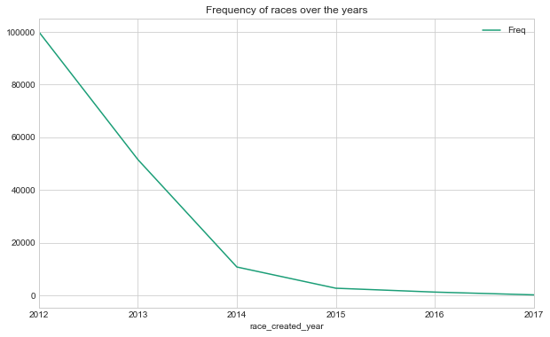

```python
race_years_counts.plot(title="Frequency of races over the years",figsize=(10,6))
```

# Average money utilized for races

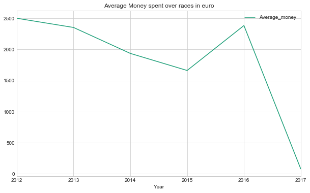

```python
race_years_avgMoney.plot(x="Year",y="Average_money",title="Average Money spent over races in euro",figsize=(10,6))
```

# Number of Races Created per year

As seen from the plot it is very clear that year 2017 had very little races. An interesting observation is exponential decrease of races. Could also mean that dataset has large information of past years as compared to the present

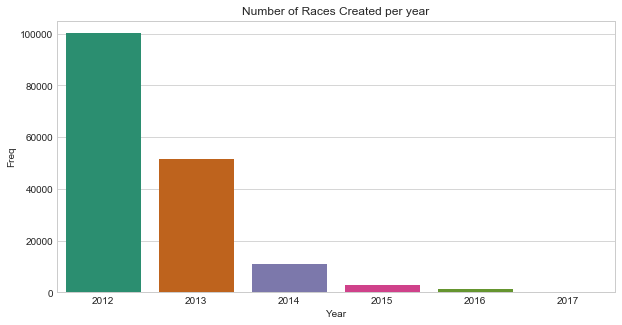

```python
plt.figure(figsize=(10,5))
plt.title("Number of Races Created per year")
sns.barplot(x=race_years_counts.Year,y=race_years_counts.Freq)
```

# Races Distribution by year

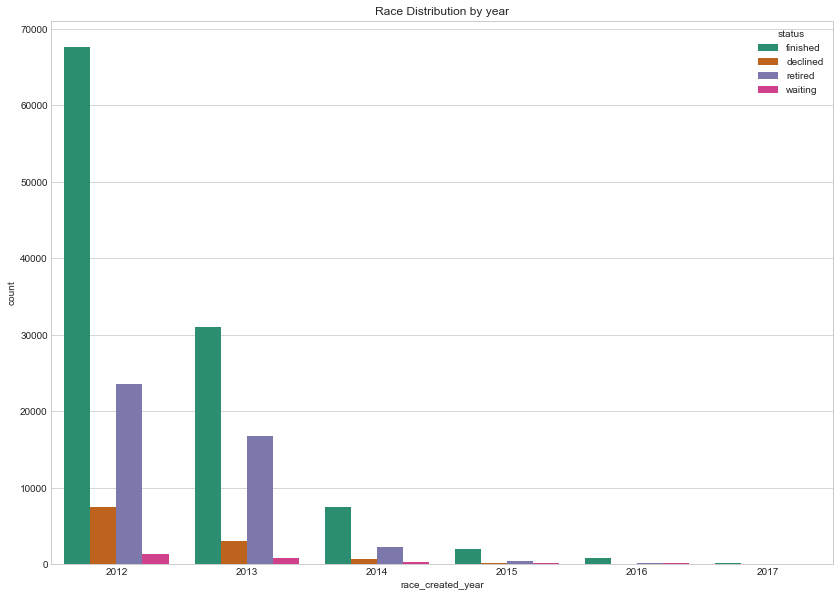

```python
plt.figure(figsize=(14,10))
plt.title("Race Distribution by year")
sns.countplot(x=race.race_created_year,data=race,hue="status")
```

```python
race.head(2)
```

|  | id | race_created | race_driven | track_id | challenger | opponent | money | fuel_consumption | winner | status | forecast | weather | race_created_year |
| --- | --- | --- | --- | --- | --- | --- | --- | --- | --- | --- | --- | --- | --- |
| 0 | 1 | 06.03.2012 | 06.03.2012 00:00 | 12 | 5 | 2 | 30 | 0.63 | 5 | finished | a:4:{s:5:"sunny";i:10;s:5:"rainy";i:70;s:8:"th... | rainy | 2012 |
| 1 | 2 | 06.03.2012 | 06.03.2012 00:03 | 12 | 5 | 4 | 30 | 0.63 | 4 | finished | a:4:{s:5:"sunny";i:70;s:5:"rainy";i:15;s:8:"th... | sunny | 2012 |

As observed from the data column for fuel_consumption in litres. A good notification was made on the data that it had to be cleaned to remove some bad data. Example:

```
1. A data value "Sep 75" is contained. For which, I have implemented a logic to keep the value 75 and remove Sep
2. A data value "03.Marz" is contained. For this, I have made it default 0 so that I can compute the mean, max and min
```

An apply function is used for the column and below function is defined to filter the values.

```python
def filter_fuel(x):
    numb = ""
    x_trim = ''.join(x.split())
    if x_trim.isalnum():
        for char in x_trim:
            if char.isdigit():
                numb+=str(char)
        return float(numb)

    elif "." in x_trim:
        if (x_trim.split(".")[0].isalpha()) or (x_trim.split(".")[1].isalpha()):
            return float(0)
        else:
            return float(x)
    return float(x)
```

```python
race["fuel_consumption"] = race.fuel_consumption.apply(filter_fuel)
```

```python
race.fuel_consumption.mean()
```

```
19.693620659752728
```

```python
race.head(5)
```

|  | id | race_created | race_driven | track_id | challenger | opponent | money | fuel_consumption | winner | status | forecast | weather | race_created_year |
| --- | --- | --- | --- | --- | --- | --- | --- | --- | --- | --- | --- | --- | --- |
| 0 | 1 | 06.03.2012 | 06.03.2012 00:00 | 12 | 5 | 2 | 30 | 0.63 | 5 | finished | a:4:{s:5:"sunny";i:10;s:5:"rainy";i:70;s:8:"th... | rainy | 2012 |
| 1 | 2 | 06.03.2012 | 06.03.2012 00:03 | 12 | 5 | 4 | 30 | 0.63 | 4 | finished | a:4:{s:5:"sunny";i:70;s:5:"rainy";i:15;s:8:"th... | sunny | 2012 |
| 2 | 3 | 06.03.2012 | 0000-00-00 00:00:00 | 3 | 10 | 5 | 30 | 0.63 | 0 | declined | a:4:{s:5:"sunny";i:70;s:5:"rainy";i:10;s:8:"th... | NaN | 2012 |
| 3 | 4 | 06.03.2012 | 06.03.2012 00:06 | 12 | 5 | 4 | 30 | 0.63 | 5 | finished | a:4:{s:5:"sunny";i:25;s:5:"rainy";i:75;s:8:"th... | sunny | 2012 |
| 4 | 5 | 06.03.2012 | 0000-00-00 00:00:00 | 12 | 4 | 5 | 30 | 0.63 | 0 | declined | a:4:{s:5:"sunny";i:45;s:5:"rainy";i:20;s:8:"th... | NaN | 2012 |

```python
race_fuel = race[race.fuel_consumption != 0.0]
```

```python
avg_fuel_year = race_fuel.groupby("race_created_year").mean()
d3= {"Year":sum_money.index,"Avg_fuel":avg_fuel_year.fuel_consumption}

race_years_avgFuel = pd.DataFrame(d3)
race_years_avgFuel.head()
```

| race_created_year | Avg_fuel | Year |
| --- | --- | --- |
| 2012 | 15.831546 | 2012 |
| 2013 | 29.270524 | 2013 |
| 2014 | 26.895848 | 2014 |
| 2015 | 24.780895 | 2015 |
| 2016 | 23.613842 | 2016 |

## Average fuel spent over races per year

This lineplot gives an indication that in the year 2013 there was high amount of usage of fuel. This could because of the races or because of the weather condition during that time

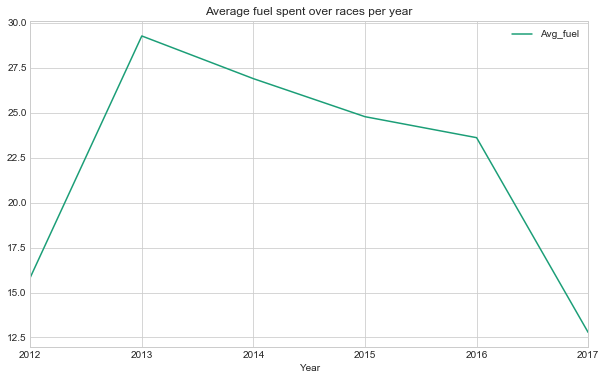

```python
race_years_avgFuel.plot(x="Year",y="Avg_fuel",title="Average fuel spent over races per year",figsize=(10,6))
```

```python
avg_fuel_status = race_fuel.groupby("status").mean()
d4 = {"status":avg_fuel_status.index,"Avg_fuel_consumption":avg_fuel_status.fuel_consumption}
avg_fuel_status_df = pd.DataFrame(d4)
avg_fuel_status_df.head()
```

| status | Avg_fuel_consumption | status |
| --- | --- | --- |
| declined | 22.315359 | declined |
| finished | 19.933176 | finished |
| retired | 22.837056 | retired |
| waiting | 24.273919 | waiting |

## Average fuel consumed group by status (Finished, Declined, Retired, Waiting)

An interesting observation to look is declined and waiting races have spent good amount of fuel

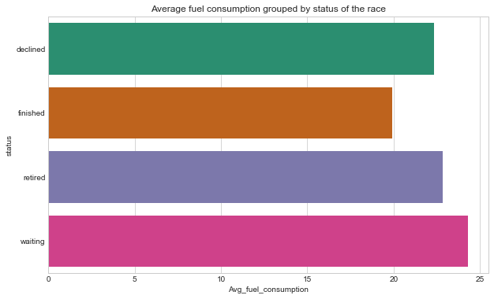

```python
plt.figure(figsize=(10,6))
plt.title("Average fuel consumption grouped by status of the race")
sns.barplot(x="Avg_fuel_consumption",y="status",data=avg_fuel_status_df)
```

```python
races_won = race[race.status == "finished"]
```

```python
races_declined = race[race.status == "declined"]
```

```python
races_declined.head(5)
```

|  | id | race_created | race_driven | track_id | challenger | opponent | money | fuel_consumption | winner | status | forecast | weather | race_created_year |
| --- | --- | --- | --- | --- | --- | --- | --- | --- | --- | --- | --- | --- | --- |
| 2 | 3 | 06.03.2012 | 0000-00-00 00:00:00 | 3 | 10 | 5 | 30 | 0.630 | 0 | declined | a:4:{s:5:"sunny";i:70;s:5:"rainy";i:10;s:8:"th... | NaN | 2012 |
| 4 | 5 | 06.03.2012 | 0000-00-00 00:00:00 | 12 | 4 | 5 | 30 | 0.630 | 0 | declined | a:4:{s:5:"sunny";i:45;s:5:"rainy";i:20;s:8:"th... | NaN | 2012 |
| 6 | 7 | 06.03.2012 | 0000-00-00 00:00:00 | 12 | 8 | 5 | 30 | 0.630 | 0 | declined | a:4:{s:5:"sunny";i:80;s:5:"rainy";i:5;s:8:"thu... | NaN | 2012 |
| 16 | 17 | 06.03.2012 | 0000-00-00 00:00:00 | 12 | 3 | 8 | 30 | 0.375 | 0 | declined | a:4:{s:5:"sunny";i:95;s:5:"rainy";i:0;s:8:"thu... | NaN | 2012 |
| 31 | 32 | 06.03.2012 | 0000-00-00 00:00:00 | 12 | 8 | 22 | 50 | 0.645 | 0 | declined | a:4:{s:5:"sunny";i:45;s:5:"rainy";i:0;s:8:"thu... | NaN | 2012 |

## Parsing forecast:

A logic for parsing forecast is implement. The serial array follows a pattern through which using string manipulations the value of the most probable forecast of the weather is extracted. This logic is very useful to extract the weather and separate columns for each of the attributes. Also, when the races are declined the status of the weather is unknown hence this logic puts a foundation to employ such a logic

### Logic:

1. In order to obtain the percentage of the weather probablities. The pattern of extraction involves to first locate the array position of respective weather using `find()`. Use this value to further take the `len(weather)` and add 4 to extract the value. Example: if String = a:4:{s:5:"sunny";i:10;s:5:"rainy";i:70;s:8:"thundery";i:0;s:5:"snowy";i:20;} and we have to extract say Sunny value which is 10. Then:
2. location of Sunny is at position 10
3. Add 10 + len(Sunny) = 5 + 4 (Because as seen 4 characters ahead we reach at the value). Store this number into a variable (Here: loc)
4. Use `x[loc:loc+3].replace(";","").replace("s","")` to extract the value where loc+3 indicate we can have percentages from 0 to 100 so 3 digit values and we will have to replace some unwanted character such as `";s}"` from the obtianed value

Below is the function behind the same logic

```python
forecast = race.forecast[0]
#a:4:{s:5:"sunny";i:10;s:5:"rainy";i:70;s:8:"thundery";i:0;s:5:"snowy";i:20;}'

def filter_forecast(x,weather):
    if "sunny" == weather:
        loc = x.find(weather) + len(weather) + 4
        return x[loc:loc+3].replace(";","").replace("s","")
    elif "rainy" == weather:
        loc = x.find(weather) + len(weather) + 4
        return x[loc:loc+3].replace(";","").replace("s","")
    elif "thundery" == weather:
        loc = x.find(weather) + len(weather) + 4
        return x[loc:loc+3].replace(";","").replace("s","")
    elif "snowy" == weather:
        loc = x.find(weather) + len(weather) + 4
        return x[loc:loc+3].replace(";","").replace("}","")
```

```python
# Just a test for the function before applying to the dataframe
filter_forecast(forecast,"snowy")
```

```
'20'
```

##### Extract the required values and add them into separate columns

```python
race["sunny"] = race.forecast.apply(filter_forecast,args=("sunny",))
race["rainy"] = race.forecast.apply(filter_forecast,args=("rainy",))
race["thundery"] = race.forecast.apply(filter_forecast,args=("thundery",))
race["snowy"] = race.forecast.apply(filter_forecast,args=("snowy",))
```

```python
race.head(2)
```

|  | id | race_created | race_driven | track_id | challenger | opponent | money | fuel_consumption | winner | status | forecast | weather | race_created_year | sunny | rainy | thundery | snowy |
| --- | --- | --- | --- | --- | --- | --- | --- | --- | --- | --- | --- | --- | --- | --- | --- | --- | --- |
| 0 | 1 | 06.03.2012 | 06.03.2012 00:00 | 12 | 5 | 2 | 30 | 0.63 | 5 | finished | a:4:{s:5:"sunny";i:10;s:5:"rainy";i:70;s:8:"th... | rainy | 2012 | 10 | 70 | 0 | 20 |
| 1 | 2 | 06.03.2012 | 06.03.2012 00:03 | 12 | 5 | 4 | 30 | 0.63 | 4 | finished | a:4:{s:5:"sunny";i:70;s:5:"rainy";i:15;s:8:"th... | sunny | 2012 | 70 | 15 | 0 | 15 |

```python
race["weather"] = race[["sunny","rainy","thundery","snowy"]].idxmax(axis=1)
```

```python
race.head(3)
```

|  | id | race_created | race_driven | track_id | challenger | opponent | money | fuel_consumption | winner | status | forecast | weather | race_created_year | sunny | rainy | thundery | snowy |
| --- | --- | --- | --- | --- | --- | --- | --- | --- | --- | --- | --- | --- | --- | --- | --- | --- | --- |
| 0 | 1 | 06.03.2012 | 06.03.2012 00:00 | 12 | 5 | 2 | 30 | 0.63 | 5 | finished | a:4:{s:5:"sunny";i:10;s:5:"rainy";i:70;s:8:"th... | rainy | 2012 | 10 | 70 | 0 | 20 |
| 1 | 2 | 06.03.2012 | 06.03.2012 00:03 | 12 | 5 | 4 | 30 | 0.63 | 4 | finished | a:4:{s:5:"sunny";i:70;s:5:"rainy";i:15;s:8:"th... | sunny | 2012 | 70 | 15 | 0 | 15 |
| 2 | 3 | 06.03.2012 | 0000-00-00 00:00:00 | 3 | 10 | 5 | 30 | 0.63 | 0 | declined | a:4:{s:5:"sunny";i:70;s:5:"rainy";i:10;s:8:"th... | sunny | 2012 | 70 | 10 | 15 | 5 |

### Based on grouping weather we can extract the percentage of races that were finished, retired, declined, waiting

```python
race.groupby("weather")["status"].value_counts(normalize=True).rename("percentage").mul(100)
```

```
weather   status
rainy     finished    65.800832
          retired     25.446650
          declined     7.015616
          waiting      1.736901
snowy     finished    65.295720
          retired     25.487047
          declined     7.394735
          waiting      1.822498
sunny     finished    65.171544
          retired     26.404642
          declined     6.698285
          waiting      1.725530
thundery  finished    66.902868
          retired     24.593890
          declined     6.771843
          waiting      1.731399
Name: percentage, dtype: float64
```

## How are the races distributed accross different weather conditions

```
Text(0,0.5,'Frequencies')
```

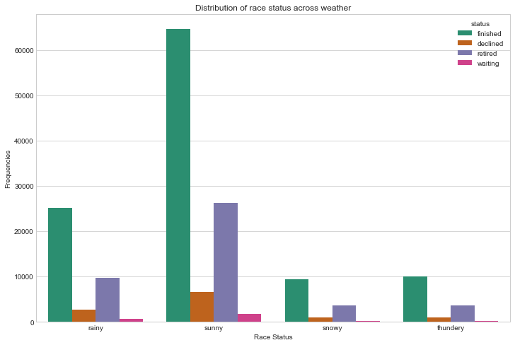

```python
plt.figure(figsize=(12,8))
plt.title("Distribution of race status across weather")
sns.countplot(x="weather",data=race,hue="status")
plt.xlabel("Race Status")
plt.ylabel("Frequencies")
```

```python
race__group_df = (race.groupby("race_created_year")["status"].
                value_counts(normalize=True).
                mul(100).
                rename("percentage").
                reset_index())
```

```python
race__group_df
```

|  | race_created_year | status | percentage |
| --- | --- | --- | --- |
| 0 | 2012 | finished | 67.638327 |
| 1 | 2012 | retired | 23.496776 |
| 2 | 2012 | declined | 7.455391 |
| 3 | 2012 | waiting | 1.409507 |
| 4 | 2013 | finished | 60.065533 |
| 5 | 2013 | retired | 32.535820 |
| 6 | 2013 | declined | 5.861140 |
| 7 | 2013 | waiting | 1.537507 |
| 8 | 2014 | finished | 69.642195 |
| 9 | 2014 | retired | 20.958472 |
| 10 | 2014 | declined | 6.294030 |
| 11 | 2014 | waiting | 3.105302 |
| 12 | 2015 | finished | 71.355311 |
| 13 | 2015 | retired | 17.912088 |
| 14 | 2015 | declined | 6.190476 |
| 15 | 2015 | waiting | 4.542125 |
| 16 | 2016 | finished | 68.987342 |
| 17 | 2016 | retired | 14.398734 |
| 18 | 2016 | waiting | 12.025316 |
| 19 | 2016 | declined | 4.588608 |
| 20 | 2017 | finished | 57.674419 |
| 21 | 2017 | waiting | 37.209302 |
| 22 | 2017 | retired | 2.790698 |
| 23 | 2017 | declined | 2.325581 |

```python
finished_df = race__group_df[race__group_df.status == "finished"]
declined_df = race__group_df[race__group_df.status == "declined"]
waiting_df = race__group_df[race__group_df.status == "waiting"]
retired_df = race__group_df[race__group_df.status == "retired"]
```

## How does the race finished change over the years

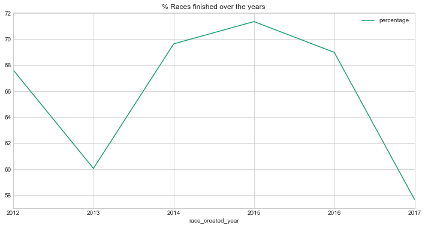

```python
finished_df.plot(x="race_created_year",y="percentage",figsize=(12,6),title="% Races finished over the years")
```

## How does the race Decline change over the years in percentage

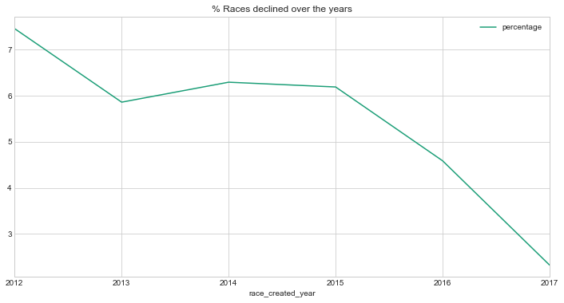

```python
declined_df.plot(x="race_created_year",y="percentage",figsize=(12,6),title="% Races declined over the years")
```

## How does the race waiting change over the years in percentage

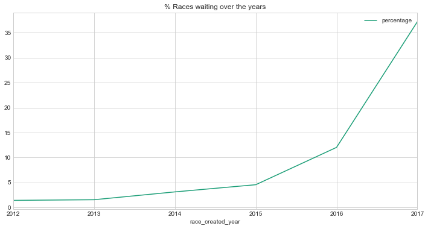

```python
waiting_df.plot(x="race_created_year",y="percentage",figsize=(12,6),title="% Races waiting over the years")
```

## How does the races which are retired change over the years in percentage

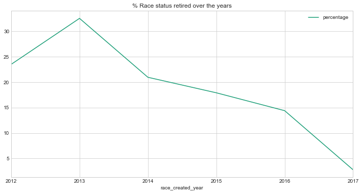

```python
retired_df.plot(x="race_created_year",y="percentage",figsize=(12,6),title="% Race status retired over the years")
```

```python
race[race.race_created_year == "2015"]
```

|  | id | race_created | race_driven | track_id | challenger | opponent | money | fuel_consumption | winner | status | forecast | weather | race_created_year | sunny | rainy | thundery | snowy |
| --- | --- | --- | --- | --- | --- | --- | --- | --- | --- | --- | --- | --- | --- | --- | --- | --- | --- |
| 162400 | 162401 | 01.01.2015 | 02.01.2015 13:15 | 3 | 13120 | 8808 | 30 | 0.570 | 8808 | finished | a:4:{s:5:"sunny";i:50;s:5:"rainy";i:25;s:8:"th... | sunny | 2015 | 50 | 25 | 25 | 0 |
| 162401 | 162402 | 01.01.2015 | 03.01.2015 15:35 | 12 | 12953 | 10070 | 75 | 79.875 | 12953 | finished | a:4:{s:5:"sunny";i:60;s:5:"rainy";i:0;s:8:"thu... | sunny | 2015 | 60 | 0 | 0 | 40 |
| 162402 | 162403 | 01.01.2015 | 02.01.2015 15:33 | 5 | 11313 | 12774 | 30 | 61.000 | 11313 | finished | a:4:{s:5:"sunny";i:5;s:5:"rainy";i:65;s:8:"thu... | rainy | 2015 | 5 | 65 | 30 | 0 |
| 162403 | 162404 | 01.01.2015 | 02.01.2015 15:32 | 5 | 11313 | 12774 | 30 | 61.000 | 11313 | finished | a:4:{s:5:"sunny";i:20;s:5:"rainy";i:40;s:8:"th... | snowy | 2015 | 20 | 40 | 35 | 5 |
| 162404 | 162405 | 01.01.2015 | 02.01.2015 15:31 | 5 | 11313 | 12774 | 30 | 61.000 | 11313 | finished | a:4:{s:5:"sunny";i:15;s:5:"rainy";i:45;s:8:"th... | thundery | 2015 | 15 | 45 | 5 | 35 |
| 162405 | 162406 | 01.01.2015 | 01.01.2015 22:02 | 12 | 12208 | 8205 | 2000 | 35.000 | 12208 | finished | a:4:{s:5:"sunny";i:90;s:5:"rainy";i:0;s:8:"thu... | sunny | 2015 | 90 | 0 | 10 | 0 |
| 162406 | 162407 | 01.01.2015 | 02.01.2015 15:13 | 12 | 7569 | 12230 | 2000 | 35.000 | 7569 | finished | a:4:{s:5:"sunny";i:25;s:5:"rainy";i:30;s:8:"th... | snowy | 2015 | 25 | 30 | 10 | 35 |
| 162407 | 162408 | 01.01.2015 | 01.01.2015 23:35 | 3 | 7569 | 12953 | 30 | 35.000 | 7569 | finished | a:4:{s:5:"sunny";i:10;s:5:"rainy";i:45;s:8:"th... | rainy | 2015 | 10 | 45 | 10 | 35 |
| 162408 | 162409 | 01.01.2015 | 01.01.2015 23:35 | 3 | 7569 | 12953 | 30 | 35.000 | 7569 | finished | a:4:{s:5:"sunny";i:35;s:5:"rainy";i:15;s:8:"th... | thundery | 2015 | 35 | 15 | 40 | 10 |
| 162409 | 162410 | 01.01.2015 | 01.01.2015 23:35 | 3 | 7569 | 12953 | 30 | 35.000 | 7569 | finished | a:4:{s:5:"sunny";i:70;s:5:"rainy";i:30;s:8:"th... | sunny | 2015 | 70 | 30 | 0 | 0 |
| 162410 | 162411 | 01.01.2015 | 02.01.2015 10:43 | 3 | 7569 | 12953 | 30 | 35.000 | 7569 | finished | a:4:{s:5:"sunny";i:55;s:5:"rainy";i:5;s:8:"thu... | sunny | 2015 | 55 | 5 | 25 | 15 |
| 162411 | 162412 | 01.01.2015 | 02.01.2015 10:43 | 3 | 7569 | 12953 | 30 | 35.000 | 7569 | finished | a:4:{s:5:"sunny";i:85;s:5:"rainy";i:5;s:8:"thu... | sunny | 2015 | 85 | 5 | 10 | 0 |
| 162412 | 162413 | 01.01.2015 | 02.01.2015 10:43 | 3 | 7569 | 12953 | 30 | 35.000 | 7569 | finished | a:4:{s:5:"sunny";i:25;s:5:"rainy";i:75;s:8:"th... | rainy | 2015 | 25 | 75 | 0 | 0 |
| 162413 | 162414 | 01.01.2015 | 02.01.2015 00:43 | 12 | 12953 | 13120 | 30 | 79.875 | 12953 | finished | a:4:{s:5:"sunny";i:30;s:5:"rainy";i:40;s:8:"th... | rainy | 2015 | 30 | 40 | 0 | 30 |
| 162414 | 162415 | 01.01.2015 | 0000-00-00 00:00:00 | 12 | 12953 | 13091 | 30 | 79.875 | 0 | retired | a:4:{s:5:"sunny";i:10;s:5:"rainy";i:0;s:8:"thu... | thundery | 2015 | 10 | 0 | 80 | 10 |
| 162415 | 162416 | 02.01.2015 | 0000-00-00 00:00:00 | 12 | 215 | 11313 | 50000 | 35.000 | 0 | retired | a:4:{s:5:"sunny";i:95;s:5:"rainy";i:5;s:8:"thu... | sunny | 2015 | 95 | 5 | 0 | 0 |
| 162416 | 162417 | 02.01.2015 | 05.01.2015 19:36 | 12 | 10343 | 80 | 300 | 35.000 | 80 | finished | a:4:{s:5:"sunny";i:70;s:5:"rainy";i:20;s:8:"th... | sunny | 2015 | 70 | 20 | 5 | 5 |
| 162417 | 162418 | 02.01.2015 | 02.01.2015 21:16 | 6 | 13090 | 13120 | 60 | 3.021 | 13090 | finished | a:4:{s:5:"sunny";i:85;s:5:"rainy";i:15;s:8:"th... | sunny | 2015 | 85 | 15 | 0 | 0 |
| 162418 | 162419 | 02.01.2015 | 02.01.2015 15:34 | 12 | 12208 | 12774 | 30 | 35.000 | 12208 | finished | a:4:{s:5:"sunny";i:15;s:5:"rainy";i:65;s:8:"th... | rainy | 2015 | 15 | 65 | 15 | 5 |
| 162419 | 162420 | 02.01.2015 | 02.01.2015 15:33 | 12 | 12208 | 12774 | 30 | 35.000 | 12208 | finished | a:4:{s:5:"sunny";i:90;s:5:"rainy";i:5;s:8:"thu... | sunny | 2015 | 90 | 5 | 5 | 0 |
| 162420 | 162421 | 02.01.2015 | 04.01.2015 20:35 | 12 | 12208 | 215 | 10000 | 35.000 | 215 | finished | a:4:{s:5:"sunny";i:80;s:5:"rainy";i:5;s:8:"thu... | sunny | 2015 | 80 | 5 | 15 | 0 |
| 162421 | 162422 | 02.01.2015 | 02.01.2015 15:35 | 12 | 12208 | 12774 | 30 | 35.000 | 12208 | finished | a:4:{s:5:"sunny";i:70;s:5:"rainy";i:10;s:8:"th... | sunny | 2015 | 70 | 10 | 5 | 15 |
| 162422 | 162423 | 02.01.2015 | 0000-00-00 00:00:00 | 12 | 12953 | 9718 | 150 | 79.875 | 0 | retired | a:4:{s:5:"sunny";i:10;s:5:"rainy";i:20;s:8:"th... | snowy | 2015 | 10 | 20 | 10 | 60 |
| 162423 | 162424 | 02.01.2015 | 0000-00-00 00:00:00 | 3 | 840 | 3001 | 30 | 49.000 | 0 | retired | a:4:{s:5:"sunny";i:25;s:5:"rainy";i:0;s:8:"thu... | snowy | 2015 | 25 | 0 | 35 | 40 |
| 162424 | 162425 | 02.01.2015 | 0000-00-00 00:00:00 | 5 | 13090 | 3001 | 50 | 1.431 | 0 | retired | a:4:{s:5:"sunny";i:45;s:5:"rainy";i:45;s:8:"th... | sunny | 2015 | 45 | 45 | 10 | 0 |
| 162425 | 162426 | 03.01.2015 | 04.01.2015 01:44 | 3 | 12774 | 13120 | 30 | 51.000 | 12774 | finished | a:4:{s:5:"sunny";i:30;s:5:"rainy";i:10;s:8:"th... | thundery | 2015 | 30 | 10 | 50 | 10 |
| 162426 | 162427 | 03.01.2015 | 04.01.2015 12:29 | 12 | 12774 | 13120 | 30 | 51.000 | 12774 | finished | a:4:{s:5:"sunny";i:50;s:5:"rainy";i:20;s:8:"th... | sunny | 2015 | 50 | 20 | 30 | 0 |
| 162427 | 162428 | 03.01.2015 | 04.01.2015 00:55 | 12 | 12774 | 12929 | 30 | 51.000 | 12929 | finished | a:4:{s:5:"sunny";i:90;s:5:"rainy";i:0;s:8:"thu... | sunny | 2015 | 90 | 0 | 5 | 5 |
| 162428 | 162429 | 03.01.2015 | 04.01.2015 00:55 | 12 | 12774 | 12929 | 30 | 51.000 | 12774 | finished | a:4:{s:5:"sunny";i:70;s:5:"rainy";i:20;s:8:"th... | sunny | 2015 | 70 | 20 | 0 | 10 |
| 162429 | 162430 | 03.01.2015 | 04.01.2015 00:55 | 12 | 12774 | 12929 | 30 | 51.000 | 12929 | finished | a:4:{s:5:"sunny";i:80;s:5:"rainy";i:0;s:8:"thu... | sunny | 2015 | 80 | 0 | 20 | 0 |
| ... | ... | ... | ... | ... | ... | ... | ... | ... | ... | ... | ... | ... | ... | ... | ... | ... | ... |
| 165100 | 165101 | 28.12.2015 | 0000-00-00 00:00:00 | 9 | 14030 | 0 | 100 | 0.640 | 0 | retired | a:4:{s:5:"sunny";i:35;s:5:"rainy";i:65;s:8:"th... | rainy | 2015 | 35 | 65 | 0 | 0 |
| 165101 | 165102 | 29.12.2015 | 02.01.2016 04:57 | 12 | 14018 | 14024 | 50 | 23.000 | 14018 | finished | a:4:{s:5:"sunny";i:90;s:5:"rainy";i:10;s:8:"th... | sunny | 2015 | 90 | 10 | 0 | 0 |
| 165102 | 165103 | 29.12.2015 | 30.12.2015 07:37 | 12 | 14018 | 14030 | 50 | 23.000 | 14018 | finished | a:4:{s:5:"sunny";i:40;s:5:"rainy";i:55;s:8:"th... | rainy | 2015 | 40 | 55 | 0 | 5 |
| 165103 | 165104 | 29.12.2015 | 29.12.2015 02:33 | 12 | 14018 | 13501 | 50 | 23.000 | 14018 | finished | a:4:{s:5:"sunny";i:75;s:5:"rainy";i:25;s:8:"th... | sunny | 2015 | 75 | 25 | 0 | 0 |
| 165104 | 165105 | 29.12.2015 | 0000-00-00 00:00:00 | 3 | 14018 | 0 | 88 | 23.000 | 0 | retired | a:4:{s:5:"sunny";i:5;s:5:"rainy";i:65;s:8:"thu... | rainy | 2015 | 5 | 65 | 5 | 25 |
| 165105 | 165106 | 29.12.2015 | 02.01.2016 04:59 | 12 | 14018 | 14024 | 100 | 23.000 | 14018 | finished | a:4:{s:5:"sunny";i:55;s:5:"rainy";i:10;s:8:"th... | sunny | 2015 | 55 | 10 | 20 | 15 |
| 165106 | 165107 | 29.12.2015 | 30.12.2015 04:50 | 12 | 14018 | 14030 | 88 | 23.000 | 14018 | finished | a:4:{s:5:"sunny";i:90;s:5:"rainy";i:0;s:8:"thu... | sunny | 2015 | 90 | 0 | 5 | 5 |
| 165107 | 165108 | 29.12.2015 | 29.12.2015 15:57 | 12 | 14024 | 14025 | 30 | 1.125 | 14024 | finished | a:4:{s:5:"sunny";i:45;s:5:"rainy";i:0;s:8:"thu... | snowy | 2015 | 45 | 0 | 5 | 50 |
| 165108 | 165109 | 29.12.2015 | 29.12.2015 16:04 | 12 | 14024 | 14025 | 30 | 1.125 | 14024 | finished | a:4:{s:5:"sunny";i:20;s:5:"rainy";i:35;s:8:"th... | rainy | 2015 | 20 | 35 | 35 | 10 |
| 165109 | 165110 | 29.12.2015 | 0000-00-00 00:00:00 | 12 | 14024 | 14030 | 50 | 1.125 | 0 | retired | a:4:{s:5:"sunny";i:65;s:5:"rainy";i:10;s:8:"th... | sunny | 2015 | 65 | 10 | 5 | 20 |
| 165110 | 165111 | 29.12.2015 | 29.12.2015 22:48 | 12 | 14025 | 14024 | 30 | 0.675 | 14024 | finished | a:4:{s:5:"sunny";i:60;s:5:"rainy";i:15;s:8:"th... | sunny | 2015 | 60 | 15 | 5 | 20 |
| 165111 | 165112 | 29.12.2015 | 0000-00-00 00:00:00 | 12 | 12953 | 0 | 3000 | 0.000 | 0 | retired | a:4:{s:5:"sunny";i:30;s:5:"rainy";i:55;s:8:"th... | rainy | 2015 | 30 | 55 | 10 | 5 |
| 165112 | 165113 | 29.12.2015 | 0000-00-00 00:00:00 | 12 | 12953 | 0 | 3000 | 0.000 | 0 | retired | a:4:{s:5:"sunny";i:45;s:5:"rainy";i:10;s:8:"th... | sunny | 2015 | 45 | 10 | 15 | 30 |
| 165113 | 165114 | 29.12.2015 | 0000-00-00 00:00:00 | 12 | 12953 | 0 | 10000 | 0.000 | 0 | retired | a:4:{s:5:"sunny";i:80;s:5:"rainy";i:15;s:8:"th... | sunny | 2015 | 80 | 15 | 5 | 0 |
| 165114 | 165115 | 29.12.2015 | 0000-00-00 00:00:00 | 12 | 12953 | 0 | 1400 | 0.000 | 0 | retired | a:4:{s:5:"sunny";i:45;s:5:"rainy";i:55;s:8:"th... | rainy | 2015 | 45 | 55 | 0 | 0 |
| 165115 | 165116 | 29.12.2015 | 02.01.2016 10:50 | 12 | 14018 | 10124 | 100 | 1.365 | 14018 | finished | a:4:{s:5:"sunny";i:35;s:5:"rainy";i:15;s:8:"th... | snowy | 2015 | 35 | 15 | 45 | 5 |
| 165116 | 165117 | 29.12.2015 | 0000-00-00 00:00:00 | 12 | 14024 | 14025 | 150 | 1.125 | 0 | declined | a:4:{s:5:"sunny";i:95;s:5:"rainy";i:5;s:8:"thu... | sunny | 2015 | 95 | 5 | 0 | 0 |
| 165117 | 165118 | 29.12.2015 | 0000-00-00 00:00:00 | 12 | 14024 | 14025 | 150 | 1.125 | 0 | declined | a:4:{s:5:"sunny";i:65;s:5:"rainy";i:30;s:8:"th... | sunny | 2015 | 65 | 30 | 5 | 0 |
| 165118 | 165119 | 29.12.2015 | 29.12.2015 23:12 | 12 | 14024 | 14025 | 300 | 1.125 | 14025 | finished | a:4:{s:5:"sunny";i:95;s:5:"rainy";i:5;s:8:"thu... | sunny | 2015 | 95 | 5 | 0 | 0 |
| 165119 | 165120 | 29.12.2015 | 0000-00-00 00:00:00 | 12 | 14024 | 3001 | 30 | 1.125 | 0 | retired | a:4:{s:5:"sunny";i:25;s:5:"rainy";i:25;s:8:"th... | thundery | 2015 | 25 | 25 | 5 | 45 |
| 165120 | 165121 | 30.12.2015 | 30.12.2015 18:41 | 12 | 14030 | 13483 | 50 | 0.780 | 13483 | finished | a:4:{s:5:"sunny";i:80;s:5:"rainy";i:20;s:8:"th... | sunny | 2015 | 80 | 20 | 0 | 0 |
| 165121 | 165122 | 30.12.2015 | 02.01.2016 04:40 | 12 | 14018 | 13501 | 84 | 1.365 | 14018 | finished | a:4:{s:5:"sunny";i:75;s:5:"rainy";i:25;s:8:"th... | sunny | 2015 | 75 | 25 | 0 | 0 |
| 165122 | 165123 | 30.12.2015 | 31.12.2015 16:25 | 12 | 14018 | 13882 | 100 | 1.365 | 14018 | finished | a:4:{s:5:"sunny";i:20;s:5:"rainy";i:60;s:8:"th... | rainy | 2015 | 20 | 60 | 10 | 10 |
| 165123 | 165124 | 30.12.2015 | 0000-00-00 00:00:00 | 3 | 11218 | 3001 | 30 | 99.000 | 0 | waiting | a:4:{s:5:"sunny";i:85;s:5:"rainy";i:0;s:8:"thu... | sunny | 2015 | 85 | 0 | 10 | 5 |
| 165124 | 165125 | 30.12.2015 | 0000-00-00 00:00:00 | 12 | 14018 | 13483 | 100 | 1.635 | 0 | declined | a:4:{s:5:"sunny";i:5;s:5:"rainy";i:45;s:8:"thu... | sunny | 2015 | 5 | 45 | 30 | 20 |
| 165125 | 165126 | 31.12.2015 | 0000-00-00 00:00:00 | 12 | 14024 | 14025 | 35 | 1.125 | 0 | retired | a:4:{s:5:"sunny";i:15;s:5:"rainy";i:55;s:8:"th... | rainy | 2015 | 15 | 55 | 10 | 20 |
| 165126 | 165127 | 31.12.2015 | 0000-00-00 00:00:00 | 12 | 14025 | 14024 | 35 | 1.035 | 0 | declined | a:4:{s:5:"sunny";i:70;s:5:"rainy";i:5;s:8:"thu... | sunny | 2015 | 70 | 5 | 10 | 15 |
| 165127 | 165128 | 31.12.2015 | 31.12.2015 11:24 | 3 | 14024 | 14025 | 30 | 29.000 | 14024 | finished | a:4:{s:5:"sunny";i:90;s:5:"rainy";i:0;s:8:"thu... | sunny | 2015 | 90 | 0 | 10 | 0 |
| 165128 | 165129 | 31.12.2015 | 31.12.2015 12:06 | 12 | 14024 | 14025 | 30 | 29.000 | 14024 | finished | a:4:{s:5:"sunny";i:25;s:5:"rainy";i:15;s:8:"th... | snowy | 2015 | 25 | 15 | 5 | 55 |
| 165129 | 165130 | 31.12.2015 | 0000-00-00 00:00:00 | 3 | 14024 | 5978 | 30 | 29.000 | 0 | retired | a:4:{s:5:"sunny";i:60;s:5:"rainy";i:10;s:8:"th... | sunny | 2015 | 60 | 10 | 10 | 20 |

2730 rows × 17 columns

```python
winner =race[((race.status != "declined") & (race.status != "retired") & (race.status != "waiting"))].winner.value_counts().head(10)
```

```python
d5 = {"UserIds":winner.index,"win_count":winner.values}
winner_df = pd.DataFrame(d5)
winner_df
```

|  | UserIds | win_count |
| --- | --- | --- |
| 0 | 48 | 6416 |
| 1 | 2866 | 3287 |
| 2 | 46 | 2821 |
| 3 | 32 | 2817 |
| 4 | 55 | 2268 |
| 5 | 5 | 2222 |
| 6 | 458 | 1525 |
| 7 | 148 | 1374 |
| 8 | 47 | 1157 |
| 9 | 3 | 1133 |

# Top 10 winners of the race

```
Text(0,0.5,'# Wins')
```

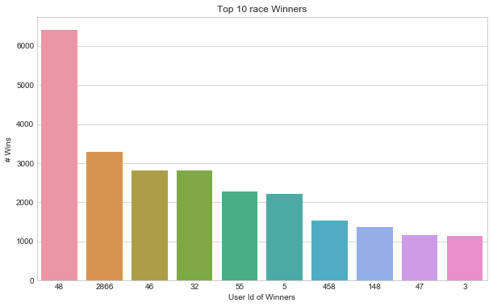

```python
plt.figure(figsize=(10,6))
plt.title("Top 10 race Winners")
sns.barplot(x="UserIds",y="win_count",data=winner_df,order=winner_df["UserIds"])
plt.xlabel("User Id of Winners")
plt.ylabel("# Wins")
```

```python
races_driven = race[race.status == "finished"]
races_driven.head(2)
```

|  | id | race_created | race_driven | track_id | challenger | opponent | money | fuel_consumption | winner | status | forecast | weather | race_created_year | sunny | rainy | thundery | snowy |
| --- | --- | --- | --- | --- | --- | --- | --- | --- | --- | --- | --- | --- | --- | --- | --- | --- | --- |
| 0 | 1 | 06.03.2012 | 06.03.2012 00:00 | 12 | 5 | 2 | 30 | 0.63 | 5 | finished | a:4:{s:5:"sunny";i:10;s:5:"rainy";i:70;s:8:"th... | rainy | 2012 | 10 | 70 | 0 | 20 |
| 1 | 2 | 06.03.2012 | 06.03.2012 00:03 | 12 | 5 | 4 | 30 | 0.63 | 4 | finished | a:4:{s:5:"sunny";i:70;s:5:"rainy";i:15;s:8:"th... | sunny | 2012 | 70 | 15 | 0 | 15 |

```python
races_driven["race_driven_year"] = races_driven.race_driven.apply(lambda x:x.split(" ")[0].split(".")[2])
```

```python
races_driven.head(2)
```

|  | id | race_created | race_driven | track_id | challenger | opponent | money | fuel_consumption | winner | status | forecast | weather | race_created_year | sunny | rainy | thundery | snowy | race_driven_year |
| --- | --- | --- | --- | --- | --- | --- | --- | --- | --- | --- | --- | --- | --- | --- | --- | --- | --- | --- |
| 0 | 1 | 06.03.2012 | 06.03.2012 00:00 | 12 | 5 | 2 | 30 | 0.63 | 5 | finished | a:4:{s:5:"sunny";i:10;s:5:"rainy";i:70;s:8:"th... | rainy | 2012 | 10 | 70 | 0 | 20 | 2012 |
| 1 | 2 | 06.03.2012 | 06.03.2012 00:03 | 12 | 5 | 4 | 30 | 0.63 | 4 | finished | a:4:{s:5:"sunny";i:70;s:5:"rainy";i:15;s:8:"th... | sunny | 2012 | 70 | 15 | 0 | 15 | 2012 |

```python
no_races_year =races_driven.groupby("race_created_year")["track_id"].sum()
```

```python
ndict = {"Year":no_races_year.index,"Counts":no_races_year.values}
df9 = pd.DataFrame(ndict)
```

```
Text(0.5,1,'Number of Races Created Per Year')
```

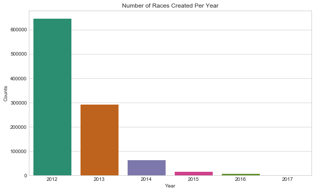

```python
plt.figure(figsize=(10,6))
sns.barplot(x="Year",y="Counts",data=df9)
plt.title("Number of Races Created Per Year")
```

```python
def filter_driven_races(x):
    if "-" in x:
        x=x.replace("-",".")

    return x.split(" ")[0].split(".")[2]
```

[output not shown]

```python
race["race_driven_year"] = race.race_driven.apply(filter_driven_races)
```

# Using scikit-learn package, we will try to predict the status based some features created

[figure not shown]

#### Scikit learn package is used to perform classification of data using machine learning algorithms. Scikit-learn is a python package and open source for usage

```python
from sklearn.model_selection import train_test_split
from sklearn.tree import DecisionTreeClassifier
from sklearn.svm import SVC
from sklearn.metrics import *
from sklearn.linear_model import LinearRegression
from sklearn.ensemble import RandomForestClassifier
import itertools
```

```python
def cm_analysis(cm,labels, figsize=(10,8)):
    """
    Generate matrix plot of confusion matrix with pretty annotations.
    The plot image is saved to disk.
    args:
      y_true:    true label of the data, with shape (nsamples,)
      y_pred:    prediction of the data, with shape (nsamples,)
      filename:  filename of figure file to save
      labels:    string array, name the order of class labels in the confusion matrix.
                 use `clf.classes_` if using scikit-learn models.
                 with shape (nclass,).
      ymap:      dict: any -> string, length == nclass.
                 if not None, map the labels & ys to more understandable strings.
                 Caution: original y_true, y_pred and labels must align.
      figsize:   the size of the figure plotted.
    """
    cm_sum = np.sum(cm, axis=1, keepdims=True)
    cm_perc = cm / cm_sum.astype(float) * 100
    annot = np.empty_like(cm).astype(str)
    nrows, ncols = cm.shape
    for i in range(nrows):
        for j in range(ncols):
            c = cm[i, j]
            p = cm_perc[i, j]
            if i == j:
                s = cm_sum[i]
                annot[i, j] = '%.1f%%\n%d/%d' % (p, c, s)
            elif c == 0:
                annot[i, j] = ''
            else:
                annot[i, j] = '%.1f%%\n%d' % (p, c)
    cm = pd.DataFrame(cm, index=labels, columns=labels)
    cm.index.name = 'Actual'
    cm.columns.name = 'Predicted'
    fig, ax = plt.subplots(figsize=figsize)
    sns.heatmap(cm, annot=annot, fmt='', ax=ax,cmap="YlGn")
```

```python
dTree = DecisionTreeClassifier()
rf = RandomForestClassifier(n_estimators=600)
```

```python
race.columns
```

```
Index(['id', 'race_created', 'race_driven', 'track_id', 'challenger',
       'opponent', 'money', 'fuel_consumption', 'winner', 'status', 'forecast',
       'weather', 'race_created_year', 'sunny', 'rainy', 'thundery', 'snowy',
       'race_driven_year'],
      dtype='object')
```

```python
X = race[['money', 'fuel_consumption', 'winner', 'race_driven_year','race_created_year','sunny', 'rainy', 'thundery', 'snowy']]
y = race["status"]
```

```python
X_train, X_test, y_train, y_test = train_test_split(X, y, test_size=0.2, random_state=101)
```

```python
dTree.fit(X_train,y_train)
```

```
DecisionTreeClassifier(class_weight=None, criterion='gini', max_depth=None,
            max_features=None, max_leaf_nodes=None,
            min_impurity_decrease=0.0, min_impurity_split=None,
            min_samples_leaf=1, min_samples_split=2,
            min_weight_fraction_leaf=0.0, presort=False, random_state=None,
            splitter='best')
```

```python
preds = dTree.predict(X_test)
```

```python
print(confusion_matrix(preds,y_test))
```

```
[[  713     0  1551   144]
 [    0 21790     0     0]
 [ 1465     0  6782   298]
 [  139     0   289   151]]
```

```python
print(classification_report(preds,y_test))
```

```
              precision    recall  f1-score   support

    declined       0.31      0.30      0.30      2408
    finished       1.00      1.00      1.00     21790
     retired       0.79      0.79      0.79      8545
     waiting       0.25      0.26      0.26       579

   micro avg       0.88      0.88      0.88     33322
   macro avg       0.59      0.59      0.59     33322
weighted avg       0.88      0.88      0.88     33322
```

```python
rf.fit(X_train,y_train)
```

```
RandomForestClassifier(bootstrap=True, class_weight=None, criterion='gini',
            max_depth=None, max_features='auto', max_leaf_nodes=None,
            min_impurity_decrease=0.0, min_impurity_split=None,
            min_samples_leaf=1, min_samples_split=2,
            min_weight_fraction_leaf=0.0, n_estimators=600, n_jobs=None,
            oob_score=False, random_state=None, verbose=0,
            warm_start=False)
```

```python
predrf = rf.predict(X_test)
```

```python
clf_mat = classification_report(predrf,y_test)
print(clf_mat)
accuracy_score(y_test,predrf)
```

```
              precision    recall  f1-score   support

    declined       0.13      0.31      0.18       970
    finished       1.00      1.00      1.00     21790
     retired       0.92      0.77      0.84     10343
     waiting       0.18      0.49      0.27       219

   micro avg       0.90      0.90      0.90     33322
   macro avg       0.56      0.64      0.57     33322
weighted avg       0.94      0.90      0.92     33322
```

```
0.9043274713402557
```

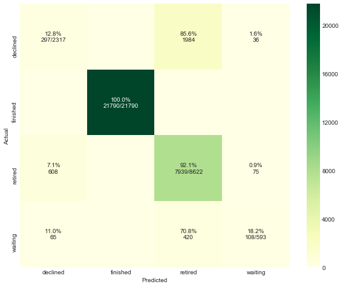

```python
# Compute confusion matrix for Random Forest
cnf_matrix = confusion_matrix(y_test, predrf)

class_names = race.status.unique()

# Plot confusion matrix
cm_analysis(cnf_matrix,sorted(class_names))
```

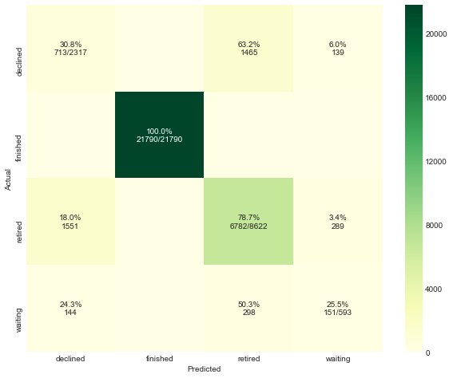

```python
# Compute confusion matrix for Decision Tree
cnf_matrix = confusion_matrix(y_test, preds)

class_names = race.status.unique()

# Plot confusion matrix
cm_analysis(cnf_matrix,sorted(class_names))
```

```python
from sklearn.model_selection import GridSearchCV
#class_weight=None, criterion='gini', max_depth=None,
 #          min_impurity_decrease=0.0, min_impurity_split=None,
  #          min_samples_leaf=1, min_samples_split=2,
   #         min_weight_fraction_leaf=0.0, presort=False, random_state=None,
    #        splitter='best'
```

```python
param_grid = {'criterion': ["gini","entropy"], 'max_depth': [3,5,7,11,15],'min_samples_leaf':[1,3,5,7]}
```

```python
gridcv = GridSearchCV(DecisionTreeClassifier(),param_grid,refit=True,verbose=2,cv=3)
gridcv.fit(X_train,y_train)
```

```
Fitting 3 folds for each of 40 candidates, totalling 120 fits
```

```
[Parallel(n_jobs=1)]: Using backend SequentialBackend with 1 concurrent workers.
```

```
[CV] criterion=gini, max_depth=3, min_samples_leaf=1 .................
[CV] .. criterion=gini, max_depth=3, min_samples_leaf=1, total=   0.4s
[CV] criterion=gini, max_depth=3, min_samples_leaf=1 .................
```

```
[Parallel(n_jobs=1)]: Done   1 out of   1 | elapsed:    0.7s remaining:    0.0s
```

[output not shown]

[output cut: 182 more lines]

[output not shown]

```
[Parallel(n_jobs=1)]: Done 120 out of 120 | elapsed:  1.6min finished
```

```
GridSearchCV(cv=3, error_score='raise-deprecating',
       estimator=DecisionTreeClassifier(class_weight=None, criterion='gini', max_depth=None,
            max_features=None, max_leaf_nodes=None,
            min_impurity_decrease=0.0, min_impurity_split=None,
            min_samples_leaf=1, min_samples_split=2,
            min_weight_fraction_leaf=0.0, presort=False, random_state=None,
            splitter='best'),
       fit_params=None, iid='warn', n_jobs=None,
       param_grid={'criterion': ['gini', 'entropy'], 'max_depth': [3, 5, 7, 11, 15], 'min_samples_leaf': [1, 3, 5, 7]},
       pre_dispatch='2*n_jobs', refit=True, return_train_score='warn',
       scoring=None, verbose=2)
```

```python
gridcv.best_params_
```

```
{'criterion': 'entropy', 'max_depth': 7, 'min_samples_leaf': 1}
```

```python
predictGridDT = gridcv.predict(X_test)
```

```python
print(classification_report(predictGridDT,y_test))
accuracy_score(predictGridDT,y_test)
```

```
              precision    recall  f1-score   support

    declined       0.01      0.55      0.02        40
    finished       1.00      1.00      1.00     21790
     retired       1.00      0.76      0.86     11384
     waiting       0.14      0.79      0.24       108

   micro avg       0.92      0.92      0.92     33322
   macro avg       0.54      0.77      0.53     33322
weighted avg       1.00      0.92      0.95     33322
```

```
0.9153412160134445
```

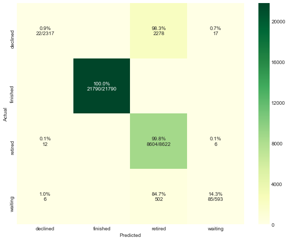

```python
# Compute confusion matrix for Grid Based DT
cnf_matrix = confusion_matrix(y_test, predictGridDT)

class_names = race.status.unique()

# Plot confusion matrix
cm_analysis(cnf_matrix,sorted(class_names))
```

```python
## Resampling to the rescue
from imblearn.over_sampling import SMOTE
```

```python
sm = SMOTE(sampling_strategy='minority',random_state=101)
```

```python
x_train_res, y_train_res = sm.fit_sample(X_train, y_train)
```

```python
decisionTreeFit = gridcv.fit(x_train_res,y_train_res)
```

```
Fitting 3 folds for each of 40 candidates, totalling 120 fits
```

```
[Parallel(n_jobs=1)]: Using backend SequentialBackend with 1 concurrent workers.
```

```
[CV] criterion=gini, max_depth=3, min_samples_leaf=1 .................
[CV] .. criterion=gini, max_depth=3, min_samples_leaf=1, total=   0.4s
[CV] criterion=gini, max_depth=3, min_samples_leaf=1 .................
```

```
[Parallel(n_jobs=1)]: Done   1 out of   1 | elapsed:    0.6s remaining:    0.0s
```

[output not shown]

[output cut: 182 more lines]

[output not shown]

```
[Parallel(n_jobs=1)]: Done 120 out of 120 | elapsed:  1.7min finished
```

```python
gridcv.cv_results_
```

[output not shown]

[output cut: 136 more lines]

[output not shown]

```python
predsSMOTE = gridcv.predict(X_test)
```

```python
print(classification_report(y_test,predsSMOTE))
accuracy_score(y_test,predsSMOTE)
```

```
              precision    recall  f1-score   support

    declined       0.31      0.10      0.15      2317
    finished       1.00      1.00      1.00     21790
     retired       0.78      0.81      0.79      8622
     waiting       0.15      0.45      0.22       593

   micro avg       0.88      0.88      0.88     33322
   macro avg       0.56      0.59      0.54     33322
weighted avg       0.88      0.88      0.87     33322
```

```
0.8781885841186003
```

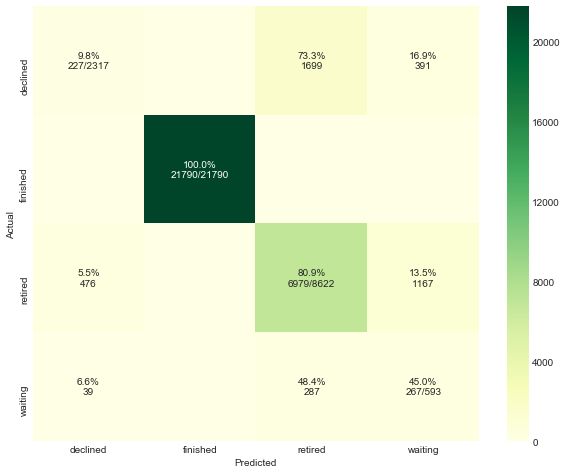

```python
# Compute confusion matrix for DT SMOTE
cnf_matrix = confusion_matrix(y_test, predsSMOTE)

class_names = race.status.unique()

# Plot confusion matrix
cm_analysis(cnf_matrix,sorted(class_names))
```

```python
from sklearn.tree import export_graphviz
from sklearn.ensemble import GradientBoostingClassifier
```

```python
len(X_train)
```

```
133287
```

```python
gbm = GradientBoostingClassifier(learning_rate=0.001, n_estimators=1500,max_depth=9, min_samples_split=1200, min_samples_leaf=60, subsample=0.85, random_state=10, max_features=7,
warm_start=True)
```

```python
gbm.fit(x_train_res,y_train_res)
```

```
GradientBoostingClassifier(criterion='friedman_mse', init=None,
              learning_rate=0.001, loss='deviance', max_depth=9,
              max_features=7, max_leaf_nodes=None,
              min_impurity_decrease=0.0, min_impurity_split=None,
              min_samples_leaf=60, min_samples_split=1200,
              min_weight_fraction_leaf=0.0, n_estimators=1500,
              n_iter_no_change=None, presort='auto', random_state=10,
              subsample=0.85, tol=0.0001, validation_fraction=0.1,
              verbose=0, warm_start=True)
```

```python
predGBMSMOTE = gbm.predict(X_test)
```

```python
print(classification_report(predGBMSMOTE,y_test))
accuracy_score(predGBMSMOTE,y_test)
```

```
              precision    recall  f1-score   support

    declined       0.00      0.00      0.00         1
    finished       1.00      1.00      1.00     21790
     retired       0.73      0.79      0.76      7992
     waiting       0.70      0.12      0.20      3539

   micro avg       0.86      0.86      0.86     33322
   macro avg       0.61      0.48      0.49     33322
weighted avg       0.90      0.86      0.86     33322
```

```
0.8558309825340615
```

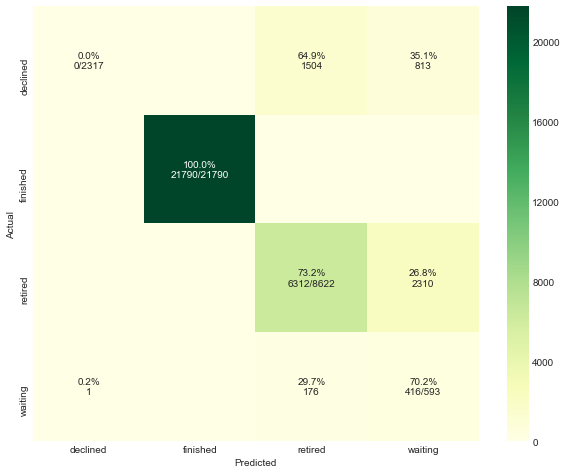

```python
# Compute confusion matrix for Random Forest
cnf_matrix = confusion_matrix(y_test, predGBMSMOTE)

class_names = race.status.unique()

# Plot confusion matrix
cm_analysis(cnf_matrix,sorted(class_names))
```

### Results:

To summarize the results obtained from the Classifications, it can be noted that Declined being treated as retired in most case having a low precision and high recall. From these observations, one option that could be done in future to the dataset is to either get more clear picture of each status through a new column which helps to discrimate it or convert the problem from a multi class prediction into a binary problem so that the predictions are either Finished or not Finished to improve the accuracy.

On the overall, still the accuracy stands good accross tree based classifiers. Also, a note should be taken that classes are imbalanced hence, a SMOTE technique is applied to the minority classes to balance the data for classification.

Hyperparameter tunning is applied to each of the model built and below are the results in terms of Accuracy,precision,recall and F1-Score

[output not shown]

To conclude, this exploration helps to understand over the years about races. The machine learning model helps to identify quickly what are finished, declined, etc.. without manual intervention. In future, it would be great to provide more understanding through data how declined/retired is different so that classifier could be improved and used globally